# slide_deck_prosperLoan slides

## Effects of Loan Characterics on Borrower's APR

##### by Lamia Alruhaimi

## Investigation Overview

In this presentation. Many visualizations will be generated on loan characteristics for the annual interest rate of borrowers. Key features are BorrowerAPR, ProsperScore, AvailableBankcardCredit, and CreditScoreRangeUpper.

## Dataset Overview

The dataset contains 113,917 loans, each row includes information on the borrow's APR, status, borrowed amount, debt, etc. This investigation will analyze the factors affecting theborrow's APR of borrowing and how each loan was taken out by which type of borrowers.

### (Visualization 1)

#### Distribution of BorrowerAPR

Keep an eye on the calculations of all the borrower's auto interest rate values, with the lowest APR around 0.05% and the highest at around 0.41%. Two numbers are found high at 0.35797% and 0.35643%.

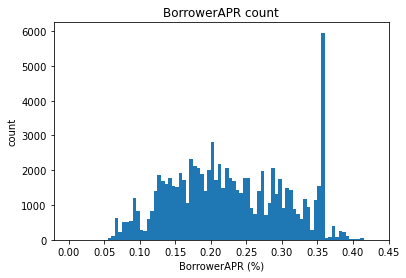

```python
bins = np.arange(0, df_loan_2['BorrowerAPR'].max(), 0.005)
plt.hist(data = df_loan_2, x = 'BorrowerAPR', bins = bins)
plt.title('BorrowerAPR count')
plt.xlabel('BorrowerAPR (%)')
plt.ylabel('count')
plt.xticks(np.arange(0, df_loan_2['BorrowerAPR'].max()+0.05, 0.05));
```

### (Visualization 2)

#### BorrowerAPR vs. ProsperScore

The higher the score, the better the rating the borrower gets. The plot shows the negative relationship between BorrowerAPR and ProsperScore. The plot shows that the higher the annual percentage rate, the lower the Prosper score. This makes sense because higher rated borrowers tend to have a lower interest rate and annual interest rate

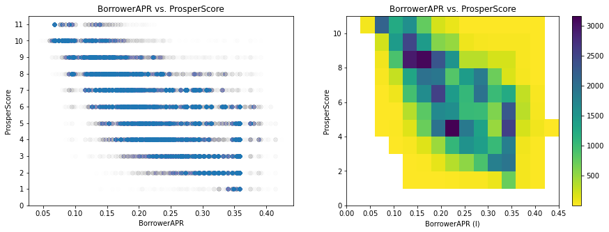

```python
# scatter and heat plot for comparing ProsperScore and BorrowerAPR.
plt.figure(figsize = [15, 5])

plt.subplot(1, 2, 1)
plt.scatter(data = df_loan_3, x = 'BorrowerAPR', y = 'ProsperScore', alpha =  0.005)
plt.yticks(np.arange(0, 12, 1))
plt.title('BorrowerAPR vs. ProsperScore')
plt.xlabel('BorrowerAPR')
plt.ylabel('ProsperScore')


plt.subplot(1, 2, 2)
bins_x = np.arange(0, df_loan_3['BorrowerAPR'].max()+0.05, 0.03)
bins_y = np.arange(0, df_loan_3['ProsperScore'].max()+1, 1)
plt.hist2d(data = df_loan_3, x = 'BorrowerAPR', y = 'ProsperScore', bins = [bins_x, bins_y],
               cmap = 'viridis_r', cmin = 0.5)
plt.colorbar()
plt.title('BorrowerAPR vs. ProsperScore')
plt.xlabel('BorrowerAPR (l)')
plt.ylabel('ProsperScore');
```

### (Visualization 3)

#### BorrowerAPR vs ProsperScore on each ProsperRatings

This visualization aids in analyzing BorrowerAPR against ProsperScore on different character ratings. The patterns show the lowest rating (HR) of borrowers with the highest APR, and highly rated (AA) borrowers having the lowest APR. This visualization distinguishes groups of people in terms of the annual percentage rate received.

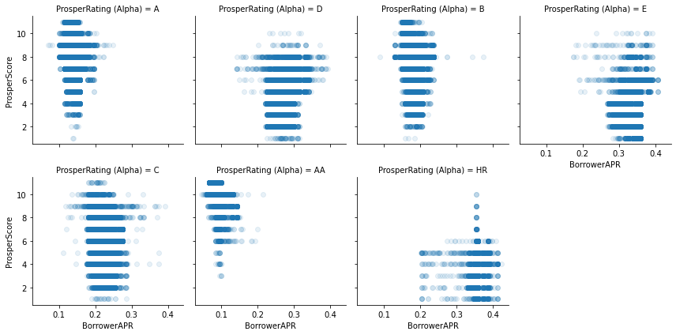

```python
g = sb.FacetGrid(data = df_loan_3, col = 'ProsperRating (Alpha)', col_wrap = 4, size = 3)
g.map(plt.scatter, 'BorrowerAPR', 'ProsperScore', alpha = 0.1)
g.set_xlabels('BorrowerAPR')
g.set_ylabels('ProsperScore')

plt.show()
```